## Getting started

To get started you will need two things: A dataset containing GPS data of at least one animal and a map containing environmental covariates for land use or sea level (usually in form of a .tif image) for the underlying area of study.

However, `amtGUI` comes with examples for both so you can get started immediately.

## Uploading data

We proceed to load the “Fisher NY” data set, a reduced version of fisher data from LaPoint et al. (2013a).

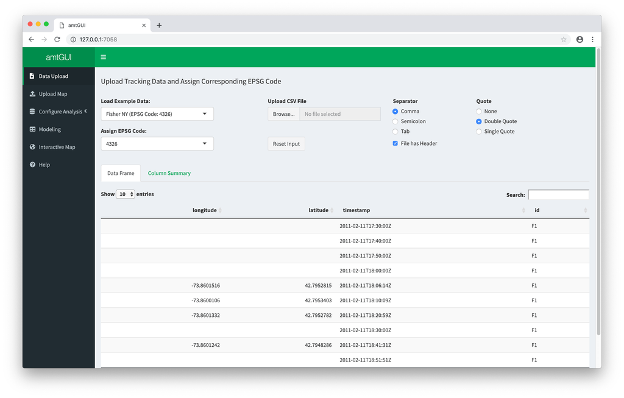

After loading your data successully, you can see it below. You can switch between your data and a column summary of it.  
**Note:** You need to assign a valid EPSG code in order to proceed here. The code for our showcase data set is 4326.

## Uploading a map

After you’ve loaded your data set you may proceed to load your landuse raster (map).

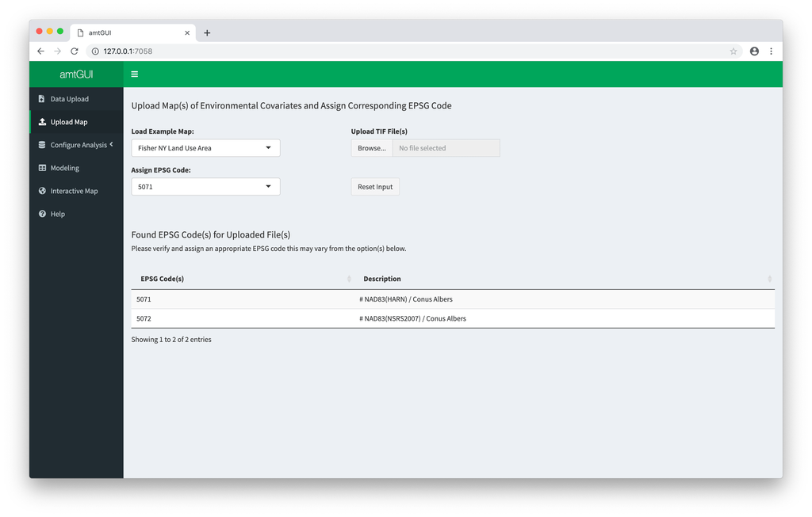

`amtGUI` tries to automatically detect all known EPSG codes of the raster and will give suggestions, however, you still need to assign one manually to proceed.

After this is done you can start configuring your analysis.

## Configuring your analysis

This section of the App is split in two tabs. Inside the first tab you can create tracks. In the second tab you can add additional covariates to your analysis.

For now let’s begin with the track creation. To create a track, you need to specifiy which columns of your data set contain the x and y-coordinates (longitude and latitude, respectively) as well as the timestamps. This is mandatory, as without a track, you can’t perform meaningful analysis of telemetry data. Additionally, you can specify an ID column for your data to identify which observations belong to which animal, or if you have multiple animals in your data set and specify ID you can filter animals out or perform analysis on a single animal. Another example could be a column you may add to your CSV file beforehand and assign it as ID say “summer” that consists of a dummy variable indicating if it’s summer or winter. To create the track now you only need to specify two more things: The resampling rate and the tolerance both in minutes for your track then you’re done. The app will immediately start working in the background to (re)calculate your track(s). You can also set a date range, the default setting is to set to the date range of your data so you don’t need to specify one to proceed. If you omit an ID value the date range will be refreshed accordingly.

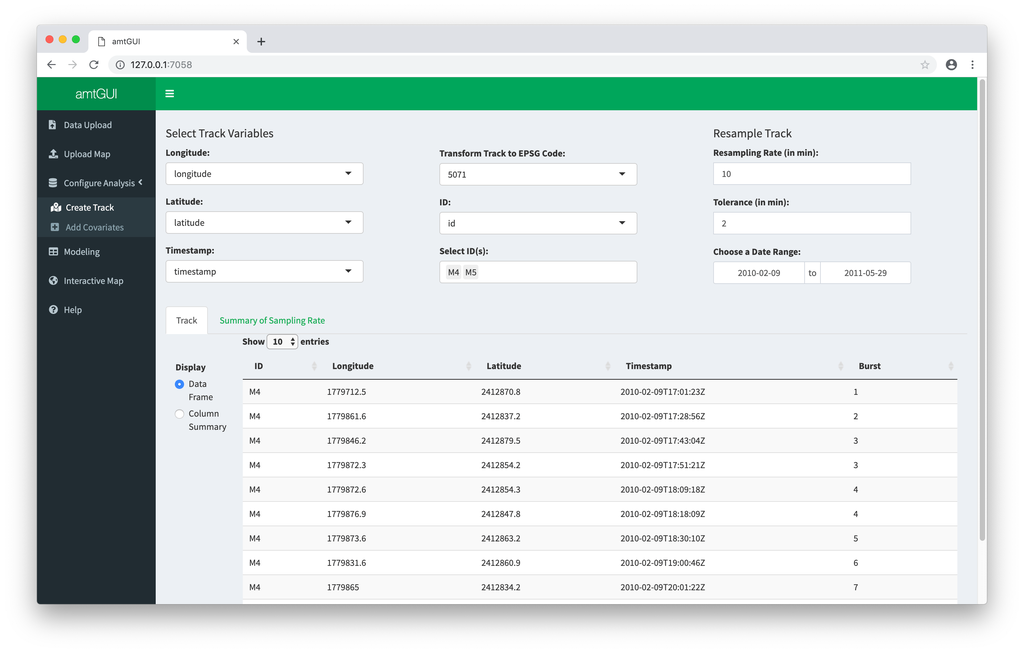

The “Add Covariates”" tab let’s you configure your analysis further. On the left side of the tab the minimum number of relocations per burst (bursts are subsets of the track with constant sampling rate, within the specified tolerance). The default here is 3, as you would need 3 relocations within one time interval to calculate the turning angle of a step (relevant for iSSF). This will be accompanied by a small table giving you information on the number of bursts remaining for each animal ID with your current settings.

On the right side you can edit the names of environmental covariates and transform them into categorical variables with a simple checkbox. You can also set to include or exclude the time of day as a categorical covariate. This will be accompanied by a table where you can see existing levels for each animal ID.

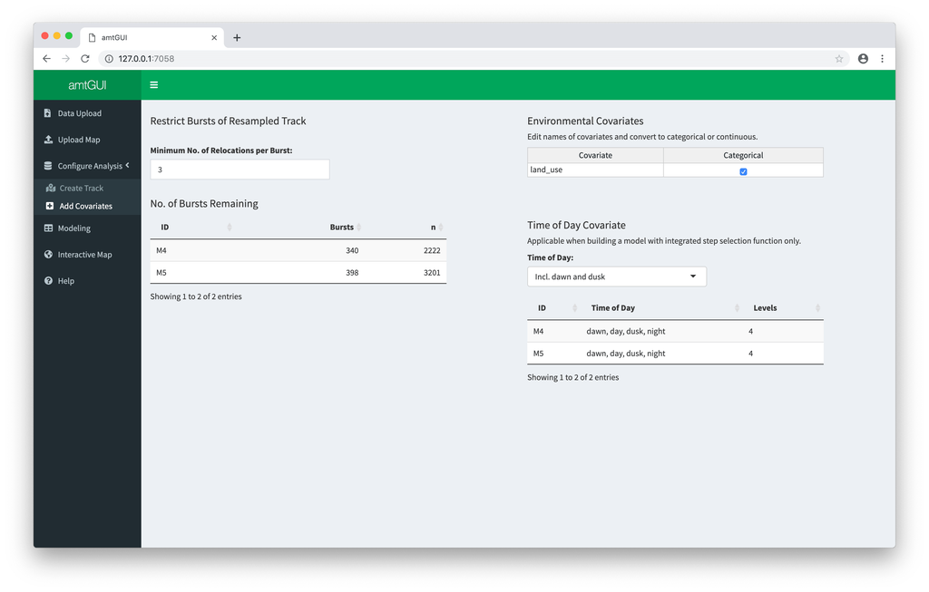

## Model Building

If you correctly set up your track before, you are now ready to fit statistical models with `amtGUI`.

On the Modeling tab you can choose between two model types: Integrated Step Selection Functions (iSSF) and Resource Selection Functions (RSF).

To fit an iSSF you need to select the input variables you want to use, where `ta_` and `sl_` are the turning angles and step length respectively, `log_sl_` is the natural logarithm of step length and `cos_ta_` the cosine of the turning angles. Besides your covariates you can specify up to 5 interaction terms. By moving the slider you can increase/decrease the number of interaction terms. Addtionally you can specify the number of random steps for each taken step (iSSF only) or the number of random points in case of the RSF. Hitting the “Fit Model” button will immediately start the fitting process (as indicated by the progress bar). Below the buttons you can see your model estimates which you can download in a csv file. Clicking the “Clear” button resets the tab so you can begin fresh. This is recommended before fitting a new model.

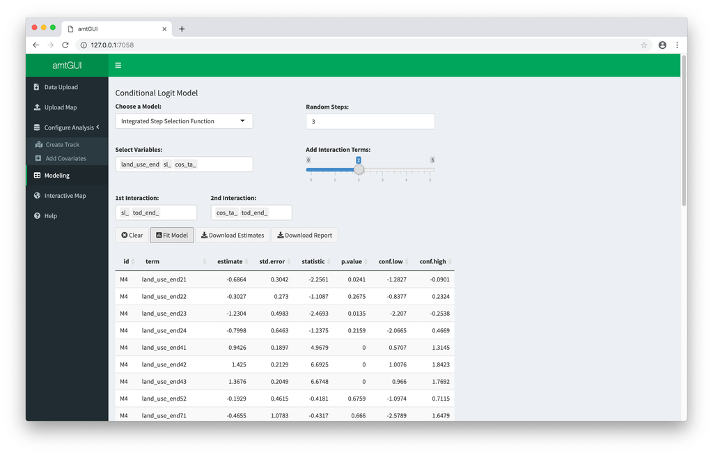

If you want to save your analysis to recreate it later you can download a report file by clicking the “Download report” button which will create a report containing all entered user inputs.

### Interpreting your results

In `amtGUI` two functions are offered for modeling. One is the Resource Selection Function (RSF) and the other the (integrated) Step Selection Function (ISSF). Interpretation of your results depends on which type of model you chose to fit. Further readings in the reference section cover this more in-depth.

#### (Integrated) Step selection functions

The interpretation depends on which covariates you have chosen and in which combination. It depends on which question you want to answer. It is also important whether covariate values are extracted at the beginning or at the end of a step, since it is possible to extract the covariate values at the beginning or at the end. If the covariates are extracted at the end of a step, then you investigate the habitat selection process. The covariates are included in the model as main effects to answer questions like: where does the animal move? If covariates are extracted at the beginning of each step they are typically included in the model as an interaction with motion properties, i.e. stride length, stride length protocol or cosine of rotation angle, to test hypotheses whether animals move faster or more directed when they start in a particular habitat? In the case that covariates are integrated into the model, which are extracted at the beginning and end of a step, questions can be asked such as: Do animals tend to stay in a particular habitat when they are already in the same habitat? (see Signer, Fieberg, and Avgar 2019)

## Interactive Map

Here you can take visualize your data set for one animal at a time or the whole data set. If you supplied the app with ID’s in the “Create Track” tab and only choose *one* active ID *or no* ID at all, you can see an interactive map here.

[figure not shown]

## References & recommended further readings

Avgar, Tal, Subhash R Lele, Jonah L Keim, and Mark S Boyce. 2017. “Relative Selection Strength: Quantifying Effect Size in Habitat-and Step-Selection Inference.” *Ecology and Evolution* 7 (14). Wiley Online Library: 5322–30.

Avgar, Tal, Jonathan R. Potts, Mark A. Lewis, and Mark S. Boyce. 2016. “Integrated Step Selection Analysis: Bridging the Gap Between Resource Selection and Animal Movement.” *Methods in Ecology and Evolution* 7 (5): 619–30. doi:10.1111/2041-210X.12528.

Duchesne, Thierry, Daniel Fortin, and Louis-Paul Rivest. 2015. “Equivalence Between Step Selection Functions and Biased Correlated Random Walks for Statistical Inference on Animal Movement.” *PloS One* 10 (4). Public Library of Science: e0122947.

LaPoint, Scott, Paul Gallery, Martin Wikelski, and Roland Kays. 2013. “Animal Behavior, Cost-Based Corridor Models, and Real Corridors.” *Landscape Ecology* 28 (8): 1615–30. doi:10.1007/s10980-013-9910-0.

Lele, Subhash R, Evelyn H Merrill, Jonah Keim, and Mark S Boyce. 2013. “Selection, Use, Choice and Occupancy: Clarifying Concepts in Resource Selection Studies.” *Journal of Animal Ecology* 82 (6). Wiley Online Library: 1183–91.

Signer, Johannes, John Fieberg, and Tal Avgar. 2019. “Animal Movement Tools (Amt): R Package for Managing Tracking Data and Conducting Habitat Selection Analyses.” *Ecology and Evolution* 9 (2). Wiley Online Library: 880–90.

Thurfjell, Henrik, Simone Ciuti, and Mark S Boyce. 2014. “Applications of Step-Selection Functions in Ecology and Conservation.” *Movement Ecology* 2 (1). BioMed Central: 4.